# Social Media Engagement Analytics

What drives likes, comments, shares and views across six platforms?

Himaja Vuchuru

14 October 2026

# Executive summary

This report analyses **5,000 social-media posts** across **six platforms** (Instagram, TikTok, Facebook, YouTube, Twitter, LinkedIn) published across **2024–2025**, and asks a simple business question: *what actually drives engagement?* The headline patterns are then **independently validated on a second, genuinely real dataset** — 23k+ real VK posts scraped from public pages (Kaggle: *VK Filtered Social Posts with Engagement Metadata*).

# 1. Introduction and objectives

**Research questions**

1. How does engagement vary by **content type**, **platform** and **posting period**?
2. How are **views, likes, comments and shares** related to one another?
3. Which account, content and timing features best predict an **engagement measure**, and how much of the variation can we explain?
4. Do the findings **generalise** to real, externally collected data?

# 2. Dataset description and source

## 2.1 Primary dataset

- **Dataset:** *Social Media Engagement Dataset* (URL: https://www.kaggle.com/datasets/aviral342/social-media-engagement-dataset).
- **Coverage:** 5,000 posts, 6 platforms, 12 content categories, Jan 2024 – Dec 2025.
- **Granularity:** one row per post.
- **Licence:** public Kaggle dataset, re-downloadable via the `kagglehub` client.
- **Note on provenance:** the Kaggle publisher states the engagement figures are *platform-realistic and generated for educational/research use*. To guard against over-claiming from a single synthetic source, this project **also validates its conclusions on real data** (§2.2, §7).

## 2.2 Validation dataset (real, from Kaggle)

- **Dataset:** *VK Filtered Social Posts with Engagement Metadata* (Kaggle, publisher `nooruzbekt`). https://www.kaggle.com/datasets/nooruzbekt/vk-social-media-posts-metadata
- **Coverage:** 23,453 **genuinely observed** posts scraped from public VK pages, 2011–2024, with likes, comments, reposts, content format, text length, hashtags and posting time.
- **Why it matters:** it is **real, observed data** (not simulated), so agreement between the two datasets strengthens the credibility of the methodology and the findings. Both datasets are sourced from **Kaggle**.

The raw files are stored at `data/raw/social_media_engagement.csv` and `data/raw/vk_posts_metadata.csv` (provenance in `data/raw/SOURCES.md`).

| Variable (primary) | Role | Description |
| --- | --- | --- |
| `Timestamp` | time | Date and time the post was published |
| `Platform` | factor | Instagram, TikTok, Facebook, YouTube, Twitter, LinkedIn |
| `Content_Type` | factor | Platform-native format (Reel, Short, Tweet, Article, …) |
| `Category` | factor | Content topic (Business, Fitness, Travel, …) |
| `Views` | numeric | Times the post was displayed (impressions) |
| `Likes` / `Comments` / `Shares` / `Saves` | numeric | Engagement actions |
| `Follower_Count` | numeric | Account size at posting time |
| `Engagement_Rate` | numeric | Supplied rate metric (validated in §4) |
| `Hashtag_Count`, `Content_Length` | numeric | Caption characteristics |
| `Sentiment`, `Influencer_Tier`, `Has_Media`, `Is_Verified` | factors | Account/content attributes |

# 3. Methodology

The analysis is organised as scripts under `R/`, all sourced by this report:

| Script | Purpose |
| --- | --- |
| `R/01_preprocess.R` | Load, audit and clean the data |
| `R/02_eda.R` | Summary statistics and eight `ggplot2` visualisations |
| `R/03_modeling.R` | Regression models, interaction test, cross-validation, robustness |
| `R/04_replication.R` | Independent validation on the real Kaggle VK dataset |

Packages: `tidyverse` (`dplyr`, `tidyr`, `readr`, `stringr`, `forcats`), `lubridate`, `ggplot2`, `scales`, `broom`, `patchwork`.

# 4. Data cleaning and preprocessing

The raw file is already tidy (one row per post), so cleaning focuses on **type coercion, feature engineering and an integrity audit**.

```r
raw_path <- file.path(DIR_RAW, "social_media_engagement.csv")
raw_data <- readr::read_csv(
  raw_path,
  show_col_types = FALSE,
  col_types = readr::cols(Timestamp = readr::col_character())
)

n_raw      <- nrow(raw_data)
n_raw_cols <- ncol(raw_data)
n_missing_raw <- sum(is.na(raw_data))
```

Timestamps are parsed to a real datetime; the stored `Hour_of_Day` and `Day_of_Week` are then checked against it as an internal-consistency test.

```r
# Parse the text timestamp once into a real datetime. All 5,000 values share the
# "YYYY-MM-DD HH:MM:SS" layout, so parsing succeeds for every row.
ts_parsed   <- suppressWarnings(lubridate::ymd_hms(raw_data$Timestamp, quiet = TRUE))
n_bad_ts    <- sum(is.na(ts_parsed))

clean_data <- raw_data %>%
  mutate(
    Post_Timestamp = ts_parsed,
    Has_Media      = as.logical(Has_Media),
    Is_Verified    = as.logical(Is_Verified)
  )

# Internal consistency: the stored hour and weekday must agree with the datetime.
n_hour_mismatch <- sum(lubridate::hour(clean_data$Post_Timestamp) != clean_data$Hour_of_Day)
n_day_mismatch  <- sum(
  as.character(lubridate::wday(clean_data$Post_Timestamp, label = TRUE,
                               abbr = FALSE, week_start = 1)) != clean_data$Day_of_Week
)
```

Several derived features make the data analysis-ready: a harmonised **content format**, calendar fields, a **posting period**, a weekend flag, and two engagement metrics.

```r
# Harmonise the platform-specific content labels (Reel / Short / Duet ... are all
# video-like) into four comparable content "formats".
format_lookup <- c(
  Video = "Video", Reel = "Video", Short = "Video", Live = "Video",
  Photo = "Image", Carousel = "Image", Story = "Image",
  Duet  = "Interactive", Stitch = "Interactive", Poll = "Interactive",
  Post  = "Text/Article", Tweet = "Text/Article", Thread = "Text/Article",
  Article = "Text/Article", Document = "Text/Article",
  `Community Post` = "Text/Article", Retweet = "Text/Article"
)

clean_data <- clean_data %>%
  mutate(
    Content_Format = unname(format_lookup[Content_Type]),
    Date           = lubridate::as_date(Post_Timestamp),
    Year           = lubridate::year(Post_Timestamp),
    Month          = lubridate::month(Post_Timestamp, label = TRUE, abbr = TRUE),
    Year_Month     = lubridate::floor_date(Post_Timestamp, "month"),
    Weekday        = lubridate::wday(Post_Timestamp, label = TRUE,
                                     abbr = FALSE, week_start = 1),
    Hour           = lubridate::hour(Post_Timestamp),
    Posting_Period = case_when(
      Hour >= 5  & Hour < 12 ~ "Morning",
      Hour >= 12 & Hour < 17 ~ "Afternoon",
      Hour >= 17 & Hour < 22 ~ "Evening",
      TRUE                   ~ "Night"
    ),
    Is_Weekend       = Weekday %in% c("Saturday", "Sunday"),
    # Volume of engagement (all interaction types)
    Total_Engagement = Likes + Comments + Shares + Saves,
    # Rate metric -- matches the supplied Engagement_Rate column (see validation)
    ER_by_Followers  = 100 * (Likes + Comments + Shares) / Follower_Count,
    ER_by_Views      = 100 * Total_Engagement / Views,
    # Data-quality flag: a post cannot be liked more often than it is seen
    Reaches_Viewers  = Views >= Total_Engagement
  )
```

```r
# Store factors with explicit levels so ordering survives the CSV round-trip.
clean_data <- clean_data %>%
  mutate(
    Platform        = factor(Platform, levels = names(PAL_PLATFORM)),
    Content_Format  = factor(Content_Format, levels = names(PAL_FORMAT)),
    Posting_Period  = factor(Posting_Period,
                             levels = c("Morning", "Afternoon", "Evening", "Night")),
    Influencer_Tier = factor(Influencer_Tier, levels = names(PAL_TIER)),
    Sentiment       = factor(Sentiment, levels = c("Negative", "Neutral", "Positive")),
    Weekday         = factor(Weekday,
                             levels = c("Monday", "Tuesday", "Wednesday", "Thursday",
                                        "Friday", "Saturday", "Sunday")),
    Has_Media       = factor(Has_Media,   levels = c(TRUE, FALSE),
                             labels = c("With media", "Without media")),
    Is_Verified     = factor(Is_Verified, levels = c(TRUE, FALSE),
                             labels = c("Verified", "Not verified"))
  )
```

The supplied `Engagement_Rate` is not taken on trust: it is re-derived from the raw counts and compared. It equals `100 * (Likes + Comments + Shares) / Follower_Count`.

```r
# Confirm how the supplied Engagement_Rate is defined, so we can trust/repurpose
# it. It equals 100 * (Likes + Comments + Shares) / Follower_Count.
rate_abs_diff <- abs(clean_data$Engagement_Rate - clean_data$ER_by_Followers)
max_rate_diff <- max(rate_abs_diff, na.rm = TRUE)
```

Finally we log the audit trail and write the analysis-ready table. Note the 295 posts flagged where total engagement exceeds views — an artefact of the data-generation process; they are **retained but flagged** and their effect is examined in §6.4.

```r
n_dup_id      <- sum(duplicated(clean_data$Post_ID))
n_missing     <- sum(is.na(clean_data))
n_views_lt_eq <- sum(!clean_data$Reaches_Viewers)

cleaning_log <- c(
  sprintf("Raw file: %s", basename(raw_path)),
  sprintf("Raw dimensions: %d rows x %d columns", n_raw, n_raw_cols),
  sprintf("Missing values in raw file: %d", n_missing_raw),
  sprintf("Duplicate Post_IDs: %d", n_dup_id),
  sprintf("Timestamps that failed to parse: %d", n_bad_ts),
  sprintf("Timestamp vs Hour_of_Day mismatches: %d", n_hour_mismatch),
  sprintf("Timestamp vs Day_of_Week mismatches: %d", n_day_mismatch),
  sprintf("Engagement_Rate == 100*(Likes+Comments+Shares)/Follower_Count (max abs diff = %.4g)",
          max_rate_diff),
  sprintf("Content labels harmonised into %d formats: %s",
          n_distinct(clean_data$Content_Format),
          paste(levels(factor(clean_data$Content_Format)), collapse = ", ")),
  sprintf("Posts flagged Views < total engagement (retained, flagged): %d",
          n_views_lt_eq),
  sprintf("Missing values after cleaning: %d", n_missing),
  sprintf("Final dimensions: %d rows x %d columns",
          nrow(clean_data), ncol(clean_data)),
  sprintf("Date range: %s to %s", min(clean_data$Date), max(clean_data$Date))
)

writeLines(cleaning_log, file.path(DIR_PROC, "cleaning_log.txt"))
cat(paste(cleaning_log, collapse = "\n"), "\n")
```

```
## Raw file: social_media_engagement.csv
## Raw dimensions: 5000 rows x 20 columns
## Missing values in raw file: 0
## Duplicate Post_IDs: 0
## Timestamps that failed to parse: 0
## Timestamp vs Hour_of_Day mismatches: 0
## Timestamp vs Day_of_Week mismatches: 0
## Engagement_Rate == 100*(Likes+Comments+Shares)/Follower_Count (max abs diff = 0.004999)
## Content labels harmonised into 4 formats: Video, Image, Interactive, Text/Article
## Posts flagged Views < total engagement (retained, flagged): 295
## Missing values after cleaning: 0
## Final dimensions: 5000 rows x 34 columns
## Date range: 2024-01-01 to 2025-12-31
```

```r
readr::write_csv(clean_data, file.path(DIR_PROC, "engagement_clean.csv"))
cat(sprintf("\n[01_preprocess] Clean data written to %s\n",
            file.path(DIR_PROC, "engagement_clean.csv")))
```

```
##
## [01_preprocess] Clean data written to H:\Temp\opencode\social-media-engagement-analytics/data/processed/engagement_clean.csv
```

# 5. Exploratory data analysis

We now reload the cleaned table (with factor levels restored) and summarise it.

```r
eda <- readr::read_csv(file.path(DIR_PROC, "engagement_clean.csv"),
                       show_col_types = FALSE) %>%
  relevel_analysis()
```

## 5.1 Overview and summary statistics

```r
overview <- tibble::tibble(
  Metric = c("Posts analysed", "Platforms", "Content formats",
             "Content categories", "Date range", "Total likes",
             "Total comments", "Total shares", "Total saves"),
  Value = c(format(nrow(eda), big.mark = ","),
            as.character(n_distinct(eda$Platform)),
            as.character(n_distinct(eda$Content_Format)),
            as.character(n_distinct(eda$Category)),
            paste(min(eda$Date), "to", max(eda$Date)),
            format(sum(eda$Likes), big.mark = ","),
            format(sum(eda$Comments), big.mark = ","),
            format(sum(eda$Shares), big.mark = ","),
            format(sum(eda$Saves), big.mark = ","))
)

numeric_vars <- c("Likes", "Comments", "Shares", "Saves", "Views",
                  "Follower_Count", "Total_Engagement",
                  "Engagement_Rate", "Hashtag_Count", "Content_Length")

summary_stats <- eda %>%
  select(all_of(numeric_vars)) %>%
  tidyr::pivot_longer(everything(), names_to = "Variable", values_to = "value") %>%
  group_by(Variable) %>%
  summarise(
    Mean   = mean(value),
    Median = median(value),
    SD     = sd(value),
    Min    = min(value),
    Q1     = quantile(value, .25),
    Q3     = quantile(value, .75),
    Max    = max(value),
    .groups = "drop"
  ) %>%
  mutate(across(where(is.numeric), ~ round(.x, 2)))

platform_summary <- eda %>%
  group_by(Platform) %>%
  summarise(
    Posts        = n(),
    Median_Likes = median(Likes),
    Median_Views = median(Views),
    Mean_ER      = round(mean(Engagement_Rate), 2),
    .groups = "drop"
  ) %>%
  arrange(desc(Mean_ER))

format_summary <- eda %>%
  group_by(Content_Format) %>%
  summarise(
    Posts    = n(),
    Mean_ER  = round(mean(Engagement_Rate), 2),
    Median_ER = round(median(Engagement_Rate), 2),
    .groups = "drop"
  ) %>%
  arrange(desc(Mean_ER))

eda_text <- c(
  "==== OVERVIEW ====",
  capture.output(print(overview)),
  "",
  "==== SUMMARY STATISTICS ====",
  capture.output(print(summary_stats)),
  "",
  "==== ENGAGEMENT BY PLATFORM ====",
  capture.output(print(platform_summary)),
  "",
  "==== ENGAGEMENT BY CONTENT FORMAT ====",
  capture.output(print(format_summary)),
  "",
  sprintf("Overall mean engagement rate (by followers): %.2f%%", mean(eda$Engagement_Rate)),
  sprintf("Overall median engagement rate (by followers): %.2f%%", median(eda$Engagement_Rate)),
  sprintf("Skewness of Total_Engagement: %.2f", {
    z <- (eda$Total_Engagement - mean(eda$Total_Engagement)) / sd(eda$Total_Engagement)
    mean(z^3)
  })
)
writeLines(eda_text, file.path(DIR_PROC, "eda_summary.txt"))
cat(paste(eda_text, collapse = "\n"), "\n")
```

```
## ==== OVERVIEW ====
## # A tibble: 9 × 2
##   Metric             Value
##   <chr>              <chr>
## 1 Posts analysed     5,000
## 2 Platforms          6
## 3 Content formats    4
## 4 Content categories 12
## 5 Date range         2024-01-01 to 2025-12-31
## 6 Total likes        37,684,192
## 7 Total comments     1,699,494
## 8 Total shares       4,176,167
## 9 Total saves        3,765,753
##
## ==== SUMMARY STATISTICS ====
## # A tibble: 10 × 8
##    Variable             Mean   Median        SD    Min        Q1       Q3    Max
##    <chr>               <dbl>    <dbl>     <dbl>  <dbl>     <dbl>    <dbl>  <dbl>
##  1 Comments            340.     212      400.     1        96      3.77e2 2.00e3
##  2 Content_Length      755.     549      576.    15       280      1.23e3 2.00e3
##  3 Engagement_Rate      12.0      2.3     71.5    0.05      1.03   6.24e0 3.51e3
##  4 Follower_Count   249959.  248930.  144593.   543    124560.     3.75e5 5.00e5
##  5 Hashtag_Count        14.8     15        8.67   0         7      2.2 e1 2.9 e1
##  6 Likes              7537.    4074.   10169.    18      1708.     7.78e3 4.99e4
##  7 Saves               753.     424      933.     5       200      8.05e2 4.99e3
##  8 Shares              835.     428.    1014.     2       177      1.11e3 5.00e3
##  9 Total_Engagement   9465.    5480.   11467.   203      2836      9.37e3 5.79e4
## 10 Views            110968.   40664.  181287.   527     18507.     8.42e4 9.99e5
##
## ==== ENGAGEMENT BY PLATFORM ====
## # A tibble: 6 × 5
##   Platform  Posts Median_Likes Median_Views Mean_ER
##   <fct>     <int>        <dbl>        <dbl>   <dbl>
## 1 TikTok      758       25268.      242344.   41.8
## 2 YouTube     479       10190       510240    10.5
## 3 Instagram  1283        4991        23930     8.12
## 4 Facebook    984        4124        41256.    7.17
## 5 Twitter     994        2366.       49372.    4.76
## 6 LinkedIn    502        1032        14278     1.75
##
## ==== ENGAGEMENT BY CONTENT FORMAT ====
## # A tibble: 4 × 4
##   Content_Format Posts Mean_ER Median_ER
##   <fct>          <int>   <dbl>     <dbl>
## 1 Interactive      891   26.2       5.36
## 2 Video           1401   14.3       3.22
## 3 Image           1221    6.69      2.11
## 4 Text/Article    1487    5.51      1.39
##
## Overall mean engagement rate (by followers): 11.96%
## Overall median engagement rate (by followers): 2.30%
## Skewness of Total_Engagement: 2.33
```

```r
missing_tbl <- eda %>%
  summarise(across(everything(), ~ sum(is.na(.x)))) %>%
  tidyr::pivot_longer(everything(), names_to = "Variable", values_to = "N_missing")
cat("\nTotal missing cells in analysis dataset:", sum(missing_tbl$N_missing), "\n")
```

```
##
## Total missing cells in analysis dataset: 0
```

```r
cor_vars <- c("Likes", "Comments", "Shares", "Saves", "Views",
              "Follower_Count", "Hashtag_Count", "Content_Length")
cor_mat <- eda %>%
  select(all_of(cor_vars)) %>%
  mutate(across(everything(), ~ log10(.x + 1))) %>%
  cor(method = "spearman") %>%
  round(2)
cat("\nSpearman correlations (log10 scale):\n")
```

```
##
## Spearman correlations (log10 scale):
```

```r
print(cor_mat)
```

```
##                Likes Comments Shares Saves Views Follower_Count Hashtag_Count
## Likes           1.00     0.46   0.25  0.50  0.40           0.00          0.00
## Comments        0.46     1.00   0.25  0.45  0.39           0.03          0.00
## Shares          0.25     0.25   1.00  0.23  0.48           0.01          0.02
## Saves           0.50     0.45   0.23  1.00  0.42           0.02          0.00
## Views           0.40     0.39   0.48  0.42  1.00           0.02          0.00
## Follower_Count  0.00     0.03   0.01  0.02  0.02           1.00          0.02
## Hashtag_Count   0.00     0.00   0.02  0.00  0.00           0.02          1.00
## Content_Length -0.30    -0.29  -0.18 -0.30 -0.27           0.00          0.01
##                Content_Length
## Likes                   -0.30
## Comments                -0.29
## Shares                  -0.18
## Saves                   -0.30
## Views                   -0.27
## Follower_Count           0.00
## Hashtag_Count            0.01
## Content_Length           1.00
```

The correlation matrix already answers research question 2: the engagement actions are **positively and moderately correlated** (log-scale Spearman $\rho$ between 0.23 and 0.50), with **views–shares** and **likes–saves** especially linked. Follower count and hashtag count are close to uncorrelated with the engagement actions, and **longer captions correlate weakly negatively** with engagement.

## 5.2 Engagement over time

[figure not shown]

```r
trend_df <- eda %>%
  group_by(Year_Month = as.Date(Year_Month)) %>%
  summarise(Mean_ER = mean(Engagement_Rate), .groups = "drop")

peak <- trend_df %>% slice_max(Mean_ER, n = 1)

fig_trend <- ggplot(trend_df, aes(Year_Month, Mean_ER)) +
  geom_line(colour = "#2166AC", linewidth = 0.9) +
  geom_point(colour = "#2166AC", size = 2) +
  geom_smooth(method = "loess", span = 0.6, se = FALSE,
              colour = "#B2182B", linetype = "dashed", linewidth = 0.8) +
  geom_hline(yintercept = mean(trend_df$Mean_ER), colour = "grey50",
             linetype = "dotted") +
  annotate("label", x = peak$Year_Month, y = peak$Mean_ER,
           label = paste0("Peak: ", format(peak$Year_Month, "%b %Y"),
                          "\n", round(peak$Mean_ER, 1), "%"),
           hjust = 0.5, vjust = -0.4, size = 3.4, fill = "#FFF3CD") +
  scale_x_date(date_labels = "%b\n%Y", date_breaks = "3 months") +
  labs(
    title = "Engagement held steady through 2024-2025",
    subtitle = "Monthly mean engagement rate (interactions per follower) across all 5,000 posts",
    x = NULL, y = "Mean engagement rate (%)",
    caption = "Dashed red = LOESS trend; dotted grey = overall mean."
  )
save_plot(fig_trend, "fig01_trend_engagement_over_time", width = 10, height = 5.5)
print(fig_trend)
```

## 5.3 Distribution of engagement

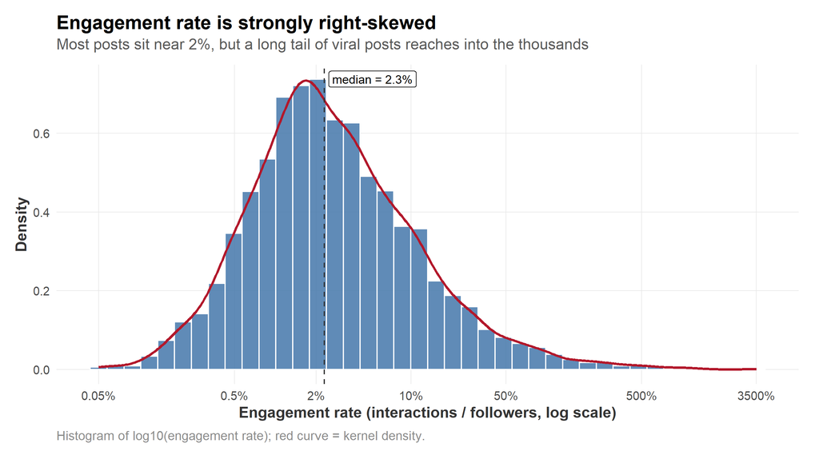

```r
med_log <- median(log10(eda$Engagement_Rate))
mean_log <- mean(log10(eda$Engagement_Rate))

fig_dist <- ggplot(eda, aes(log10(Engagement_Rate))) +
  geom_histogram(aes(y = after_stat(density)), bins = 40,
                 fill = "#4477AA", colour = "white", alpha = 0.85) +
  geom_density(colour = "#B2182B", linewidth = 1) +
  geom_vline(xintercept = med_log, linetype = "dashed", colour = "grey20") +
  annotate("label", x = med_log, y = Inf,
           label = paste0("median = ", round(10^med_log, 2), "%"),
           vjust = 1.4, hjust = -0.05, size = 3.3, fill = "white") +
  scale_x_continuous(
    breaks = log10(c(0.05, 0.5, 2, 10, 50, 500, 3500)),
    labels = c("0.05%", "0.5%", "2%", "10%", "50%", "500%", "3500%")) +
  labs(
    title = "Engagement rate is strongly right-skewed",
    subtitle = "Most posts sit near 2%, but a long tail of viral posts reaches into the thousands",
    x = "Engagement rate (interactions / followers, log scale)",
    y = "Density",
    caption = "Histogram of log10(engagement rate); red curve = kernel density."
  )
save_plot(fig_dist, "fig02_distribution_engagement_rate")
print(fig_dist)
```

*Figure 2. The engagement rate is strongly right-skewed — most posts cluster near 2%, with a long viral tail. This justifies the log transforms used throughout.*

## 5.4 Comparison by content type and platform

[figure not shown]

```r
fig_format <- eda %>%
  mutate(Content_Format = fct_reorder(Content_Format, Engagement_Rate, median)) %>%
  ggplot(aes(Content_Format, Engagement_Rate, fill = Content_Format)) +
  geom_boxplot(outlier.shape = NA, alpha = 0.85, width = 0.65) +
  geom_jitter(width = 0.12, alpha = 0.08, size = 0.7, colour = "grey20") +
  stat_summary(fun = median, geom = "point", shape = 23, size = 3,
               fill = "white", colour = "grey10") +
  coord_cartesian(ylim = c(0, 12)) +
  scale_fill_manual(values = PAL_FORMAT, guide = "none") +
  scale_y_continuous(labels = function(x) paste0(x, "%")) +
  labs(
    title = "Video posts draw the strongest engagement",
    subtitle = "Boxes ordered by median; white diamonds mark medians (outliers hidden)",
    x = NULL, y = "Engagement rate (%)",
    caption = "Y-axis zoomed to 0-12% with coord_cartesian(); values above are clipped for readability."
  )
save_plot(fig_format, "fig03_comparison_engagement_by_content")
print(fig_format)
```

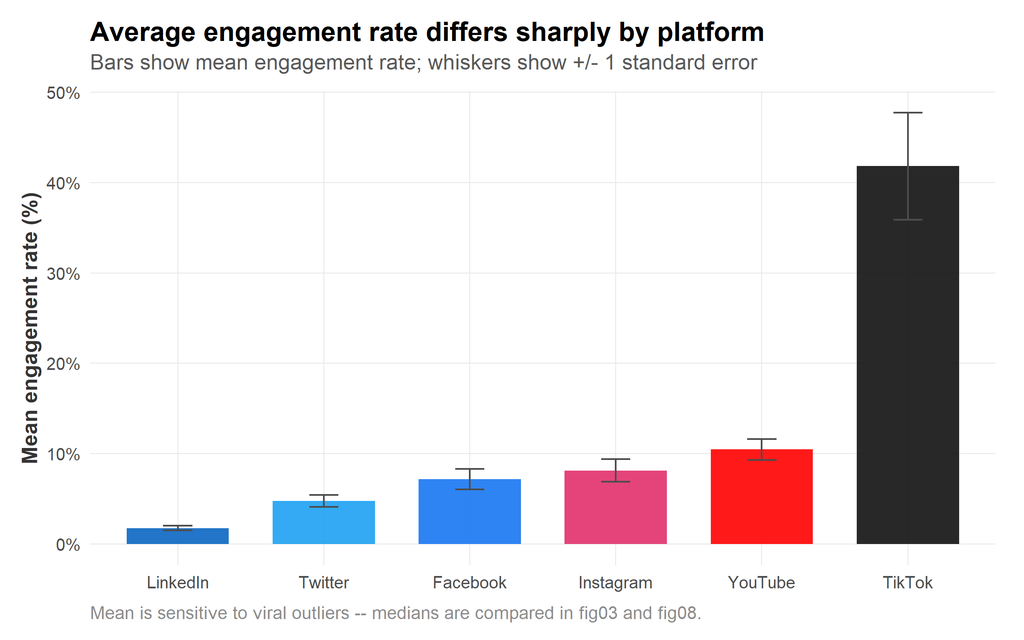

```r
platform_plot <- eda %>%
  group_by(Platform) %>%
  summarise(Mean_ER = mean(Engagement_Rate),
            SE = sd(Engagement_Rate) / sqrt(n()), .groups = "drop")

fig_platform <- ggplot(platform_plot, aes(fct_reorder(Platform, Mean_ER), Mean_ER,
                                          fill = Platform)) +
  geom_col(alpha = 0.9, width = 0.7) +
  geom_errorbar(aes(ymin = Mean_ER - SE, ymax = Mean_ER + SE),
                width = 0.2, colour = "grey30") +
  scale_fill_manual(values = PAL_PLATFORM, guide = "none") +
  scale_y_continuous(labels = function(x) paste0(x, "%")) +
  labs(
    title = "Average engagement rate differs sharply by platform",
    subtitle = "Bars show mean engagement rate; whiskers show +/- 1 standard error",
    x = NULL, y = "Mean engagement rate (%)",
    caption = "Mean is sensitive to viral outliers -- medians are compared in fig03 and fig08."
  )
save_plot(fig_platform, "fig04_comparison_engagement_by_platform")
print(fig_platform)
```

*Figure 4. Mean engagement rate by platform. TikTok leads by a wide margin; LinkedIn trails. The large means (and wide error bars) reflect viral outliers — hence the median-based views below.*

## 5.5 Relationships among views, likes and shares

[figure not shown]

```r
rho <- cor(log10(eda$Views), log10(eda$Likes), method = "spearman")

fig_scatter <- ggplot(eda, aes(Views, Likes, colour = Platform)) +
  geom_point(alpha = 0.45, size = 1.3) +
  geom_smooth(method = "lm", se = FALSE, linewidth = 0.8, formula = y ~ x) +
  scale_x_log10(labels = comma_short) +
  scale_y_log10(labels = comma_short) +
  scale_colour_manual(values = PAL_PLATFORM) +
  annotate("label", x = min(eda$Views) * 1.6, y = max(eda$Likes) * 0.9,
           label = paste0("Spearman rho = ", round(rho, 2)),
           hjust = 0, size = 3.6, fill = "white") +
  labs(
    title = "More views almost always means more likes",
    subtitle = "Likes rise with reach on every platform, but the slope differs by platform",
    x = "Views (log scale)", y = "Likes (log scale)",
    caption = "Each line = ordinary least-squares fit for that platform on log-log axes."
  )
suppressMessages(save_plot(fig_scatter, "fig05_scatter_views_vs_likes"))
suppressMessages(print(fig_scatter))
```